# PCA Analysis of the Iris Dataset

# 4. Run PCA (with scaling)

Now we will run PCA using the `prcomp()` function.

## Why do we scale the data?

Our variables (**Sepal.Length, Sepal.Width, Petal.Length, Petal.Width**) are measured in the same unit,  
but their **ranges can still be different**.

If we do **not scale the data**:

- Variables with **larger values can dominate the PCA result**.

So we use:

- **scale. = TRUE** → standardizes the variables (makes them comparable).

## Run PCA

```r
# Run PCA with scaling
pca_result <- prcomp(iris_numeric, scale. = TRUE)
```

## Show PCA variance information

```r
summary(pca_result)
```

```
## Importance of components:
##                           PC1    PC2     PC3     PC4
## Standard deviation     1.7084 0.9560 0.38309 0.14393
## Proportion of Variance 0.7296 0.2285 0.03669 0.00518
## Cumulative Proportion  0.7296 0.9581 0.99482 1.00000
```

## Check the PCA summary

The summary tells us how much **variance** each principal component explains.

Usually, **PC1** explains the most variance, then **PC2**, and so on.

### How to read the summary (simple)

In the output you will see:

- **Standard deviation** of each PC
- **Proportion of Variance** → how much variance each PC explains
- **Cumulative Proportion** → total variance explained up to that PC

For a **2D PCA plot**, we usually use **PC1 and PC2** because they explain the most variance.

# 5. Extract PCA Scores

After running PCA, we need the **coordinates of each sample** in the new PCA space.

These coordinates are called **PCA scores**.

They tell us where each sample is located on:

- PC1
- PC2
- PC3
- PC4

These scores are stored inside the PCA object.

## Extract PCA scores

```r
# Convert PCA scores into a data frame
pca_scores <- as.data.frame(pca_result$x) #Now pca_scores contains the PCA coordinates of each sample.

# Add Species information to the PCA dataset
pca_scores$Species <- iris$Species
```

## Add the Species label

Remember that we did not include **Species** in the PCA calculation.

However, we still want to use it to **color the PCA plot**.

Now our dataset contains:

- **PCA coordinates** (PC1, PC2, PC3, PC4)
- **Species label**

This allows us to **visualize the PCA results by species**.

# 6. Plot PCA (PC1 vs PC2)

Now we will visualize the PCA results using a **2D scatter plot**.

We will plot:

- **PC1** on the x-axis
- **PC2** on the y-axis
- color points by **Species**

## Create the PCA plot

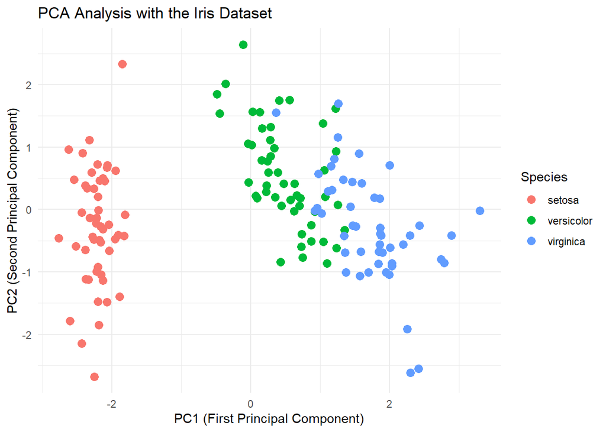

```r
# PCA plot: PC1 vs PC2
ggplot(pca_scores, aes(x = PC1, y = PC2, color = Species)) +
  geom_point(size = 3) +
  xlab("PC1 (First Principal Component)") +
  ylab("PC2 (Second Principal Component)") +
  ggtitle("PCA Analysis with the Iris Dataset") +
  theme_minimal()
```

## How to interpret the PCA plot (simple)

The PCA plot helps us understand **how similar or different the samples are**.

- Points that are **close together** represent samples that are **similar**.
- Points that are **far apart** represent samples that are **different**.
- If species form **separate clusters**, PCA can help **distinguish them**.

In the iris dataset:

- **setosa** samples are usually **clearly separated** from the other species.
- **versicolor** and **virginica** are **closer together** and may **partially overlap**.

### How to read a PCA plot

- The **x-axis (PC1)** represents the direction with the **largest variance** in the dataset.
- The **y-axis (PC2)** represents the **second largest variance**.
- Each point represents **one sample** in the dataset.
- Colors indicate **different groups or species**.